# Citibike Explanatory Analysis

## by Charles Ikenna Abara

## Investigation Overview

The goal of this presentation is to communicate the findings of my exploratory analysis. This slide will give insight into Citi bikers' ride patterns and the effect of gender and user type on bike rides and ride duration.

## Dataset Overview

The wrangled dataset consists of bike-sharing data in New york city from January 2014 to December 2016. The data set has 31546302 rows and 9 features. The features are listed below:

- Trip Duration(minutes):**duration**
- Start Time and Date: **start_time**
- Start Station Name: **start_station_name**
- Stop Time and Date: **stop_time**
- End Station Name: **end_station_name**
- Bike ID: **bike_id**
- User Type (Customer = 24-hour pass or 3-day pass user; Subscriber = Annual Member): **usertype**
- Gender (Zero=unknown; 1=male; 2=female): **gender**
- Year of Birth: **user_birth_year**

## Distribution of Ride Duration

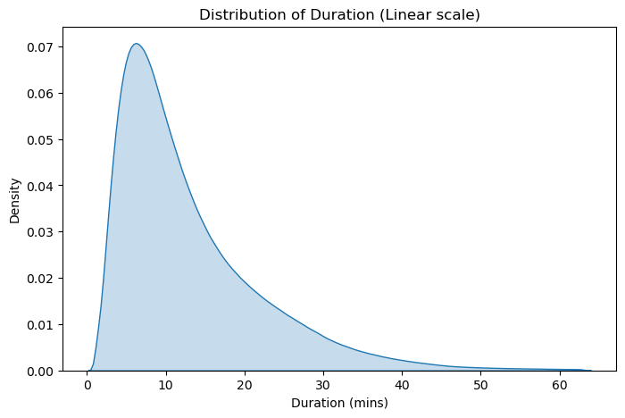

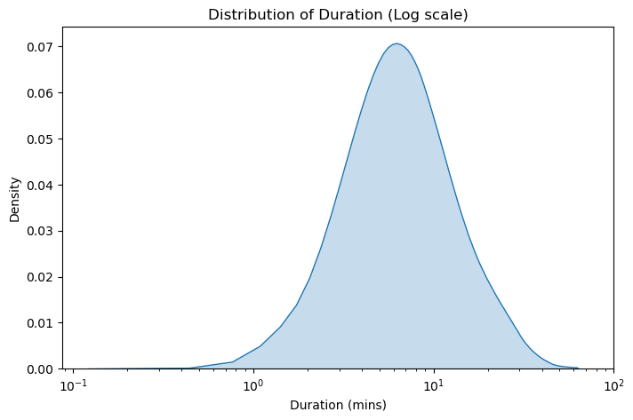

## When do Citi Bikers Ride?

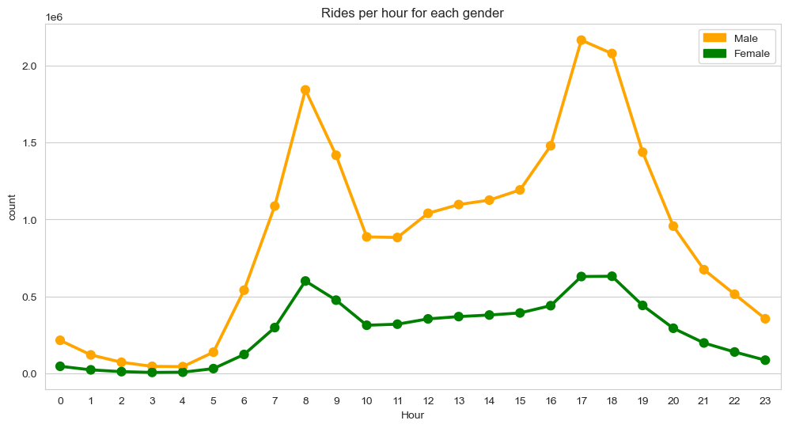

[figure not shown]

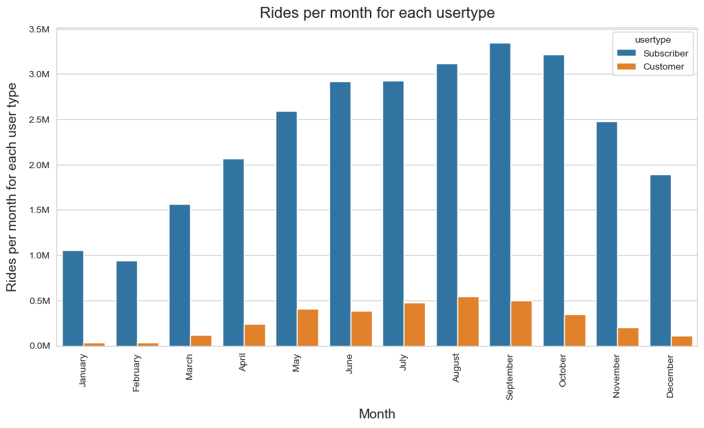

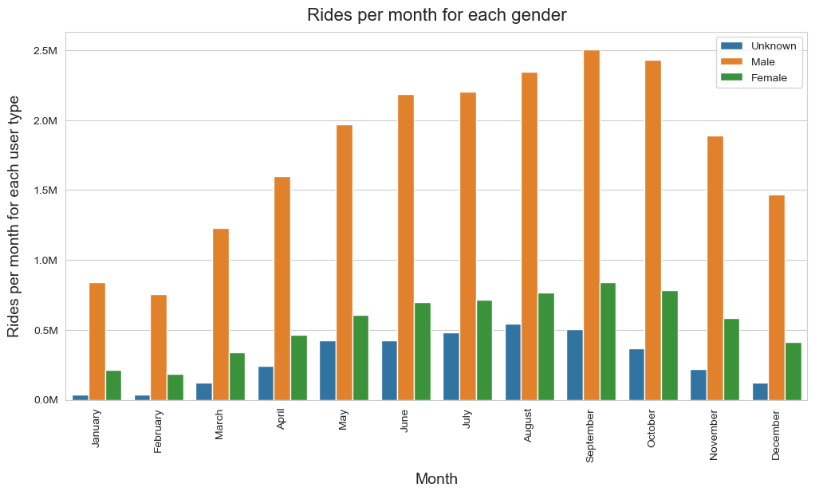

## Multivariate Exploration of Duration, Gender and User Type

This violin plot shows the effect of gender and user type on duration.

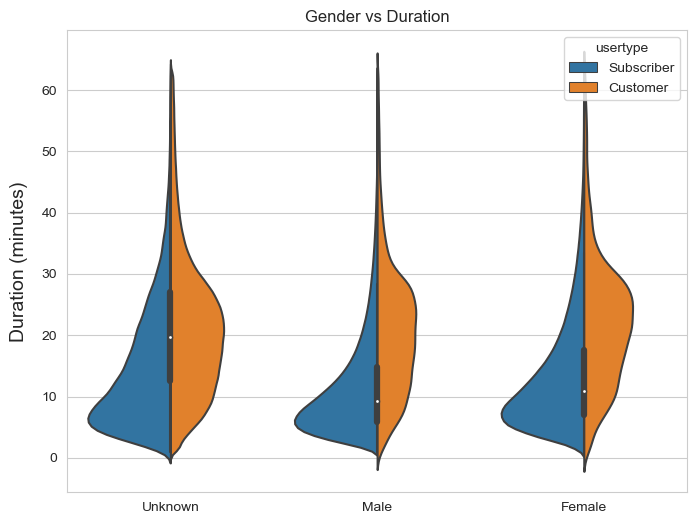